# lumber strength report

Yunfeng Yang

2023-06-07

# Damage model

The original model is

$$\begin{equation}\label{eq: original
model}
y^* = y \cdot I\{c \cdot y > l\} + \alpha \cdot y \cdot I\{c \cdot y
< l\}
\end{equation}$$

# Smooth function

Note that we have the indicator function in the model we might consider the smooth function:
$$\begin{equation}\label{eq: trans function}
S(x;s) = \frac{1}{1 + \exp(-s \cdot x)}
\end{equation}$$
, where $s$ is the smoothing hyper-parameter to control the smoothness.

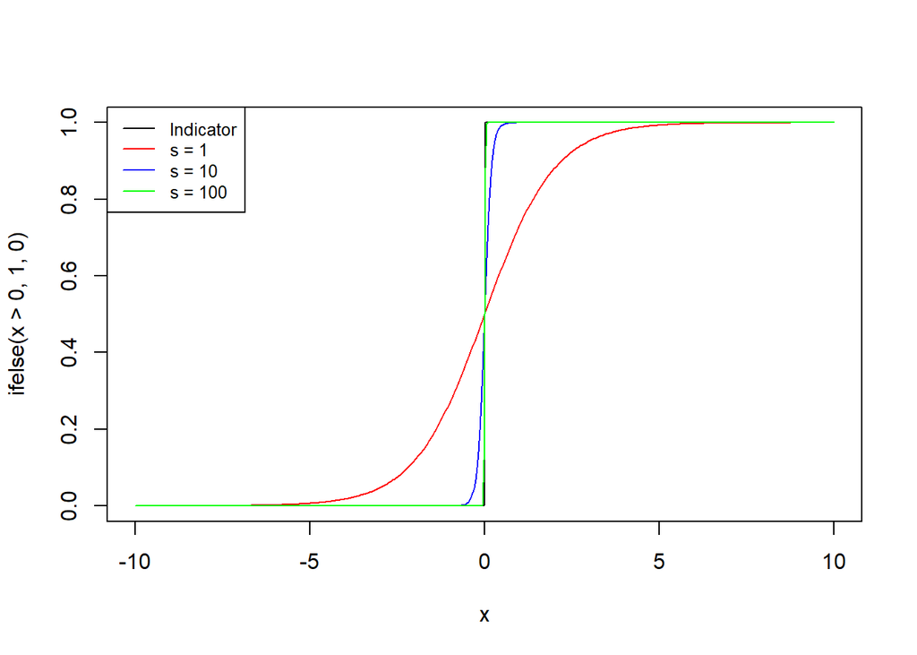

```r
smooth_ind <- function(x,s){
  return(1/(1+exp(-x*s)))
}
x <- seq(from = -10, to= 10, length.out = 500)
plot(x,ifelse(x>0,1,0),type = "l")
lines(x,sapply(x,smooth_ind, s = 1),type = "l",col = "red")
lines(x,sapply(x,smooth_ind, s = 10),type = "l",col = "blue")
lines(x,sapply(x,smooth_ind, s = 100),type = "l",col = "green")
legend("topleft", legend=c("Indicator", "s = 1", "s = 10", "s = 100"),
       col=c("black","red", "blue","green"), lty=1, cex=0.8)
```

Then the model becomes
$$y^* = y \cdot \frac{1}{1 + \exp(-s\cdot(cy-l))} + \alpha \cdot y \cdot
\frac{1}{1 + \exp(-s\cdot(l-cy))}$$
# the plot

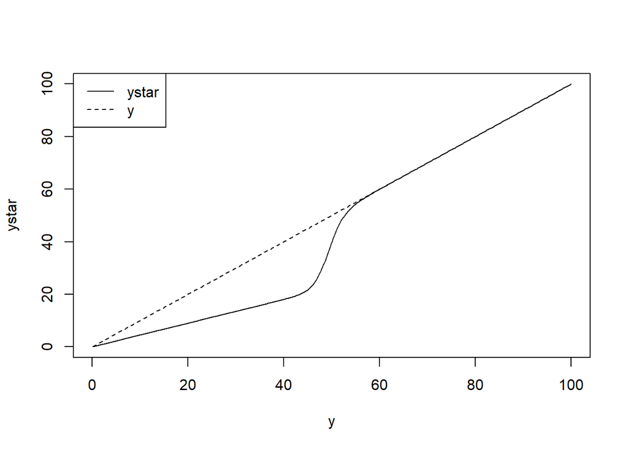

```r
### new

mu <- 48
sigma <- 19
#y <- rnorm(N,mean = mu, sd = sigma)
y <- seq(from = 0.1, to = 100, length = 500)
l <-  32
alpha <- 0.45
c <- 0.65
s <- 1
ystar <- y*smooth_ind(c*y-l,s )+ alpha*y*smooth_ind(l-c*y,s)

plot(y,ystar,type = 'l',lty = 1)
lines(y,y,lty = 2)
legend("topleft", legend = c("ystar","y"),lty=1:2)
```

We have $y \geq y^*$.

The lumber have three groups:

- Group 1: $y <l$, $y^* < l$, i.e., $y^* <y < l$. The lumber pieces are broken blow the proof loading.
- Group 2: $y >l$, $y^* < l$, i.e. $y^*<l<y$. The lumber pieces are broken during the proof loading process. This groups we only knows how many pieces.
- Group 3: $y >l$, $y^* > l$, i.e. $l<y^*<y$. The lumber pieces survived in the proof-loading. And then we destruct them to test their strength.

# The PDF calculation

Given $Y \sim N(\mu, \sigma^2)$, $Y^* = h(Y)$. Then the pdf of $Y^*$,
$$f_{Y^*}(y^*) = f_{Y}(h^{-1}(y^*))|\frac{d}{dy^*}h^{-1}(y^*)|,$$
where $f_Y()$ is the pdf of $Y$, i.e., normal.

Following this, We need the numerical function of $h^{-1}(y^*)$, and its numerical gradient $\frac{d}{dy^*}h^{-1}(y^*)$. (The analytical form doesn’t seem available.)

```r
#' The smooth function for the indicator function, which is also called "sigmoid function".
#'
#' @param x, the variable
#' @param s, the hyper parameter, higher s means closer the indicator function
#' @returns the smoothed value.

smooth_ind <- function(x,s){
  return(1/(1+exp(-x*s)))
}



#' The damage model, smoothed version of
#' "y* = y* I(c*x > l) + alpha * y * I(c*x < l)"
#'
#' @param y, the original strength
#' @param alpha, the damage parameter
#' @param l, the proof loading level
#' @param c, the threshold parameter. Damage effects happen exceeding c.
#' @param s, the temperature parameter for s
#' @return, the weakened y*, y*<y.
dmg_model <- function(y,alpha,l,c,s){
  return(y*smooth_ind(c*y-l,s)+ alpha*y*smooth_ind(l-c*y,s))
}

#' The damage-inverse model, given a weakened ystar, find the original y
#'
#' @param ystar, the weakened strength
#' @param alpha, the damage parameter
#' @param l, the proof loading level
#' @param c, the threshold parameter. Damage effects happen exceeding c.
#' @param s, the temperature parameter for s
#' @return, the original y, y>y*.
dmg_inverse <- function(ystar,alpha,l,c,s){
  uniroot((function (x) dmg_model(x,alpha,l,c,s) - ystar), lower = 0, upper = 1000)$root
}
# the abs gradient at damage-inverse
dmg_inverse_grad <- function(ystar,alpha,l,c,s){
  abs(numDeriv::grad(func = (function(x) dmg_inverse(x,alpha,l,c,s)),
                     x  = ystar))
}
# dmg_inverse_grad(42,a lpha,l,c,s)
# ystar <- y*smooth_ind(c*y-l)+ alpha*smooth_ind(l-c*y)

dmglik <- function(ystar,alpha,l,c,s,mu,sigma){
  y <- dmg_inverse(ystar,alpha,l,c,s)
  dnorm(y, mean = mu, sd = sigma, log = TRUE)+ log(dmg_inverse_grad(ystar,alpha,l,c,s))
}
```

```r
## plot
set.seed(8888)
# the orignal sample size
N <- 300
mu <- 48
sigma <- 19
#y <- rnorm(N,mean = mu, sd = sigma)
l <-  32
# alpha <- 0.9
# c <- 0.8
alpha <- 0.45
c <- 0.65
s <- 1

## data

y <- rnorm(N, mean = mu, sd = sigma )
y <- y[y>0]
y_obs <- list()
# group 1, y^* <y < l
y_obs$group1 <- y[which(y < l)]
# group 2, y^*<l<y
group23 <- y[which(y > l)]
group23_star <- dmg_model(group23,alpha,l,c,s)
y_obs$group2 <- length(group23[which(group23 > l &group23_star < l)])
y_obs$group3 <- group23_star[which(group23_star >l)]

negdmglik_model <- function(theta){
  mu <- theta[1]
  sigma <- theta[2]
  alpha <- theta[3]
  c <- theta[4]

  lik1 <- sum(dnorm(y_obs$group1,mean = mu, sd = sigma, log = TRUE))
  lik2 <- y_obs$group2 * log(
    pnorm(dmg_inverse(l,alpha,l,c,s), mean = mu, sd = sigma) -
      pnorm(l, mean = mu, sd = sigma)
  )
  #lik2 <- 0
  lik3 <- sum(sapply(y_obs$group3,dmglik,alpha,l,c,s,mu,sigma))
  return(-lik1-lik2-lik3)
  #return (-lik3)
}

theta0 <- c(mu,sigma,alpha,c)
```

```r
optimout <- optim(theta0,negdmglik_model,method = "L-BFGS-B",
                  lower = rep(0.1,4),upper = c(Inf,Inf,1,Inf))

# theta0 is true theta
rbind(theta0,optimout$par)
```

```
##            [,1]     [,2]      [,3]      [,4]
## theta0 48.00000 19.00000 0.4500000 0.6500000
##        47.99939 19.00907 0.4435964 0.6394996
```

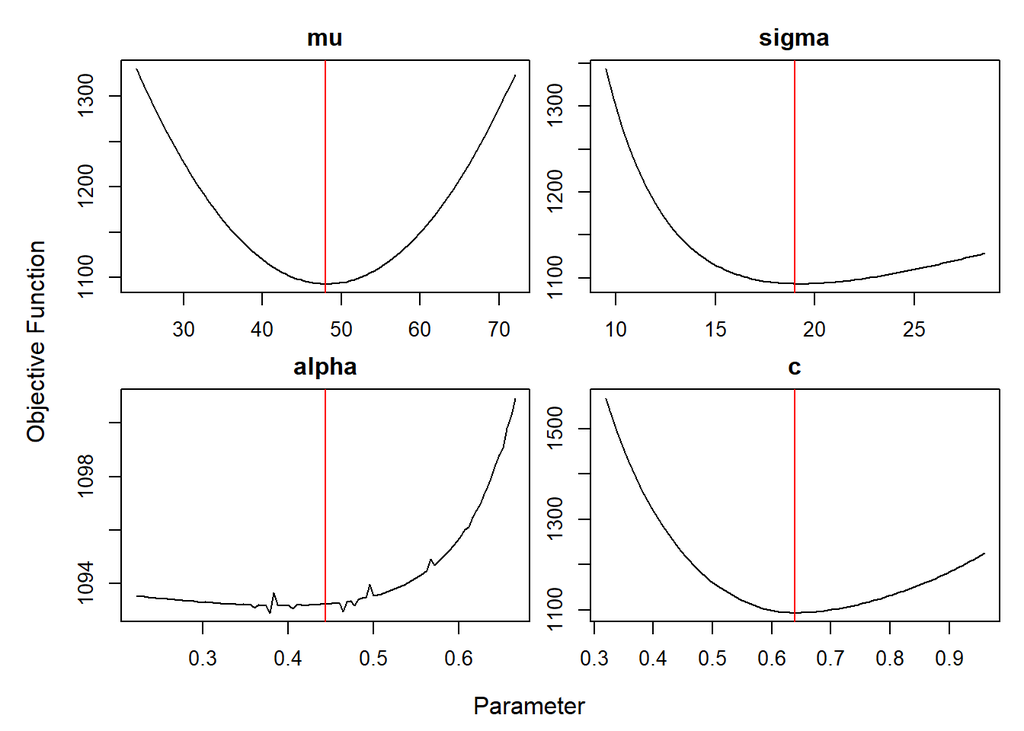

```r
optimCheck::optim_proj(optimout$par,
                       negdmglik_model,xrng = .5,
                       xnames = c("mu","sigma","alpha","c"))
```

# Find why negative loglikelihood with respect to alpha has little bumps

```r
negdmglik_alpha<- function(theta){

  alpha <- theta


  lik1 <- sum(dnorm(y_obs$group1,mean = mu, sd = sigma, log = TRUE))
  lik2 <- y_obs$group2 * log(
    pnorm(dmg_inverse(l,alpha,l,c,s), mean = mu, sd = sigma) -
      pnorm(l, mean = mu, sd = sigma)
  )
  #lik2 <- 0
  lik3 <- sum(sapply(y_obs$group3,dmglik,alpha,l,c,s,mu,sigma))
  return(-lik1-lik2-lik3)
}
```

First, I only look into alpha log-likelihood, holding the other three parameters as true values. The specific $\alpha \in [0.15,0.2]$ region shows some bumps.

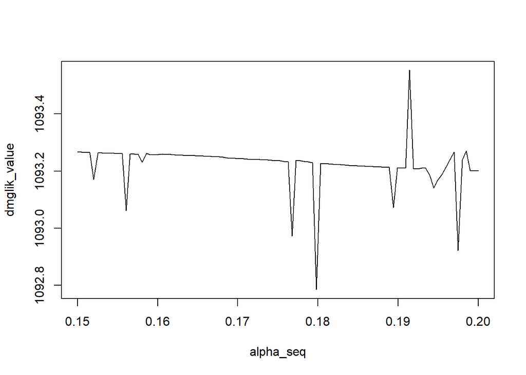

```r
alpha_seq <- seq(from = 0.15, to = 0.2, length = 100)
dmglik_value <- sapply(alpha_seq,negdmglik_alpha)
plot(alpha_seq,dmglik_value,type = "l")
```

When alpha goes from 0.1798 to 0.1800 with 0.0002 changes, the log-likelihood changes 0.44!

```r
negdmglik_alpha(0.1798)
```

```
## [1] 1092.785
```

```r
negdmglik_alpha(0.18)
```

```
## [1] 1093.227
```

```r
negdmglik_alpha(0.1798) - negdmglik_alpha(0.18)
```

```
## [1] -0.4426151
```

Then I try to find which observation causes this 0.44 change

```r
sapply(y_obs$group3,dmglik,0.1798,l,c,s,mu,sigma)-sapply(y_obs$group3,dmglik,0.180,l,c,s,mu,sigma)
```

```
##   [1] -7.071788e-05 -1.184593e-07  0.000000e+00 -1.095034e-04 -1.060534e-04
##   [6] -4.152110e-08 -6.111770e-05 -3.752699e-07 -6.844022e-05  0.000000e+00
##  [11] -1.241696e-06  0.000000e+00 -8.700723e-07 -4.078405e-05 -8.480598e-08
##  [16] -6.704277e-08  0.000000e+00 -2.051994e-08 -6.260829e-06  0.000000e+00
##  [21] -7.881575e-06 -9.567443e-08 -1.906952e-06 -3.545173e-08  0.000000e+00
##  [26] -6.118891e-05  0.000000e+00 -3.848245e-06 -1.194541e-04  0.000000e+00
##  [31] -6.675571e-06  0.000000e+00 -2.306520e-05 -6.768002e-05 -7.016465e-05
##  [36] -1.305786e-06 -7.602797e-05 -2.091036e-06 -7.573132e-06 -4.566361e-07
##  [41]  0.000000e+00 -7.440525e-05  0.000000e+00 -2.217873e-06 -6.777663e-05
##  [46]  0.000000e+00 -1.000586e-05 -1.873630e-07  0.000000e+00  4.427259e-01
##  [51] -7.023666e-05 -5.555355e-07 -2.149156e-08 -8.095551e-05 -2.211716e-05
##  [56] -6.822108e-05 -3.575910e-06 -6.808509e-05 -5.647160e-07 -3.034991e-05
##  [61]  0.000000e+00 -3.310394e-06 -3.052421e-05 -6.731147e-06 -1.179300e-08
##  [66] -9.670009e-05  0.000000e+00 -5.432513e-06 -6.921056e-05 -4.744105e-06
##  [71] -7.041421e-07 -1.146188e-05  0.000000e+00  0.000000e+00 -6.152945e-05
##  [76]  0.000000e+00 -2.816343e-07 -7.546229e-08 -4.996666e-05 -1.486186e-08
##  [81]  0.000000e+00  0.000000e+00 -1.755832e-07 -1.080847e-08  0.000000e+00
##  [86] -6.741145e-05 -1.812284e-06 -7.022982e-05  0.000000e+00  0.000000e+00
##  [91] -6.850444e-05 -4.730136e-05 -1.498605e-05 -1.737727e-04  0.000000e+00
##  [96]  0.000000e+00 -1.947293e-05 -6.446900e-05 -3.052941e-05  0.000000e+00
## [101] -1.392414e-05 -3.120414e-05  0.000000e+00 -7.695748e-05 -1.439929e-07
## [106] -5.014143e-06  0.000000e+00  0.000000e+00 -2.583928e-07  0.000000e+00
## [111] -6.423277e-05  0.000000e+00 -5.917001e-05 -2.566336e-05 -1.081064e-05
## [116] -1.553291e-04 -7.678313e-06  0.000000e+00  0.000000e+00 -6.748129e-05
## [121] -1.021479e-04  0.000000e+00 -4.768660e-07 -6.313286e-08 -6.788543e-05
## [126] -2.096601e-05 -6.552521e-05  0.000000e+00  0.000000e+00 -7.099688e-05
## [131]  0.000000e+00 -7.764156e-05 -2.483229e-06 -5.436868e-06  0.000000e+00
## [136] -4.011971e-06 -4.323654e-05 -1.514449e-05 -6.773195e-05 -6.103320e-05
## [141]  0.000000e+00 -1.801289e-04  0.000000e+00  0.000000e+00
```

```r
# order the difference
order(sapply(y_obs$group3,dmglik,0.1798,l,c,s,mu,sigma)-
  sapply(y_obs$group3,dmglik,0.180,l,c,s,mu,sigma),decreasing = TRUE )
```

```
##   [1]  50   3  10  12  17  20  25  27  30  32  41  43  46  49  61  67  73  74
##  [19]  76  81  82  85  89  90  95  96 100 103 107 108 110 112 118 119 122 128
##  [37] 129 131 135 141 143 144  84  65  80  18  53  24   6 124  16  78  15  22
##  [55]   2 105  83  48 109  77   8  40 123  52  59  71  13  11  36  87  23  38
##  [73]  44 133  62  57  28 136  70 106  68 134  19  31  64  39 117  21  47 115
##  [91]  72 101  93 138  97 126  55  33 114  60  63  99 102  14 137  92  79 113
## [109] 140   7  26  75 111  98 127  86 120  34 139  45 125  58  56   9  91  69
## [127]  35  88  51   1 130  42  37 104 132  54  66 121   5   4  29 116  94 142
```

So the 50th observation of `y_obs$group3` has the largest difference.

```r
dmglik(y_obs$group3[50],0.1798,l,c,s,mu,sigma) - dmglik(y_obs$group3[50],0.18,l,c,s,mu,sigma)
```

```
## [1] 0.4427259
```

What if we remove the 50th observation?

```r
sum(sapply(y_obs$group3[-50],dmglik,0.1798,l,c,s,mu,sigma))-sum(sapply(y_obs$group3[-50],dmglik,0.180,l,c,s,mu,sigma))
```

```
## [1] -0.003616576
```

Now if alpha changes 0.0002, the log-likelihood changes 0.003. Much smoother!

## Why that observation has bumps

Recall that the pdf of ystar. Given $Y \sim N(\mu, \sigma^2)$, $Y^* = h(Y)$. Then the pdf of $Y^*$,
$$f_{Y^*}(y^*) = f_{Y}(h^{-1}(y^*))|\frac{d}{dy^*}h^{-1}(y^*)|,$$
where $f_Y()$ is the pdf of $Y$, i.e., normal.

So the log-pdf has two parts:

- the normal part: $\log(f_{Y}(h^{-1}(y^*)))$
- the gradient part: $\log(|\frac{d}{dy^*}h^{-1}(y^*)|)$

### the normal part

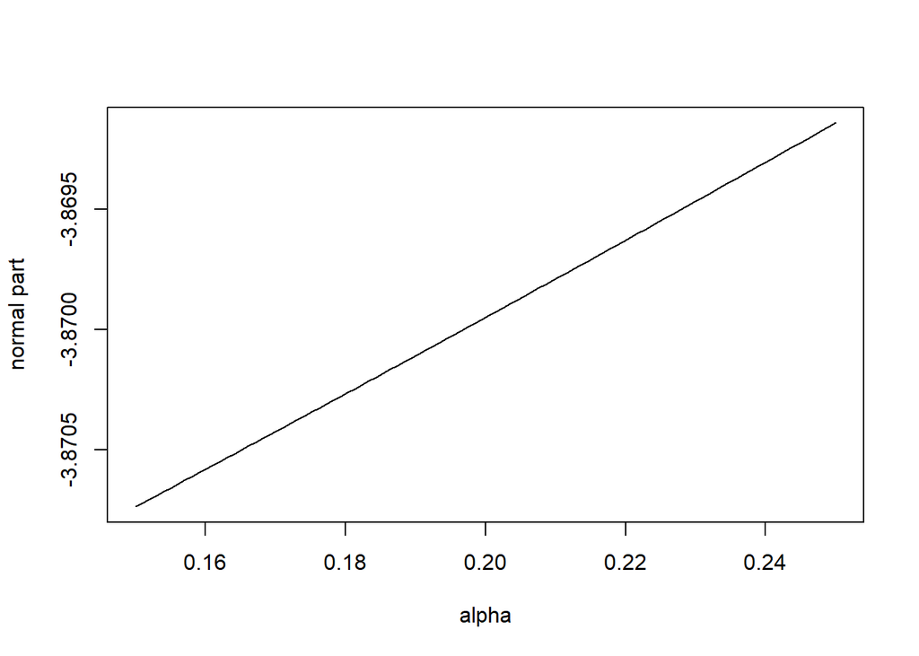

```r
alpha_seq <- seq(from = 0.15, to = 0.25, length = 100)
plot(alpha_seq,
     sapply(alpha_seq, function(alpha){dnorm(dmg_inverse(y_obs$group3[50],alpha,l,c,s), mean = mu, sd = sigma, log = TRUE)
}),
type = "l",xlab = "alpha", ylab = "normal part")
```

It is smooth.

### the gradient part

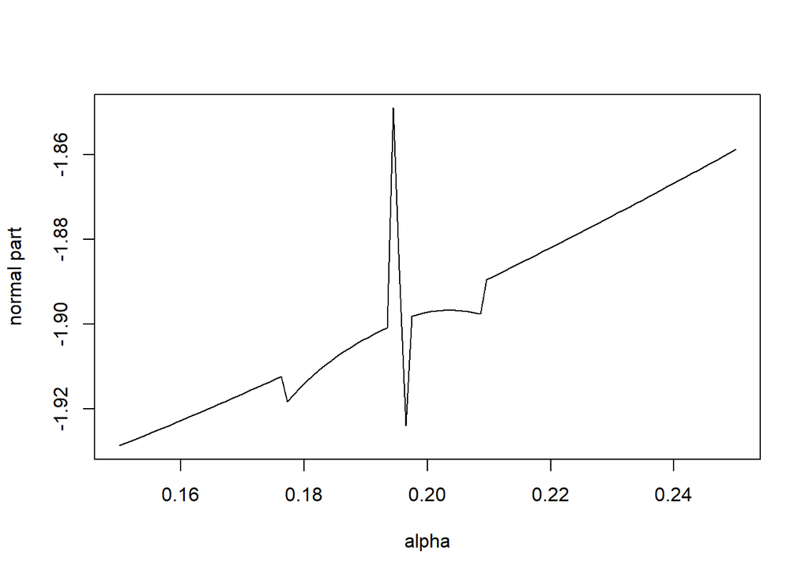

```r
# test the gradient part
alpha_seq <- seq(from = 0.15, to = 0.25, length = 100)
plot(alpha_seq,
     sapply(alpha_seq, function(alpha){log(dmg_inverse_grad(y_obs$group3[50],alpha,l,c,s))
}),
     type = "l",xlab = "alpha", ylab = "normal part")
```

It has bumps.

```r
sapply(c(0.1798,0.18), function(alpha){log(dmg_inverse_grad(y_obs$group3[50],alpha,l,c,s))
})
```

```
## [1] -1.471325 -1.914054
```

The bump from the loglikelihood does come from the gradient.

# What about remove the 50th observation and test the likelihood?

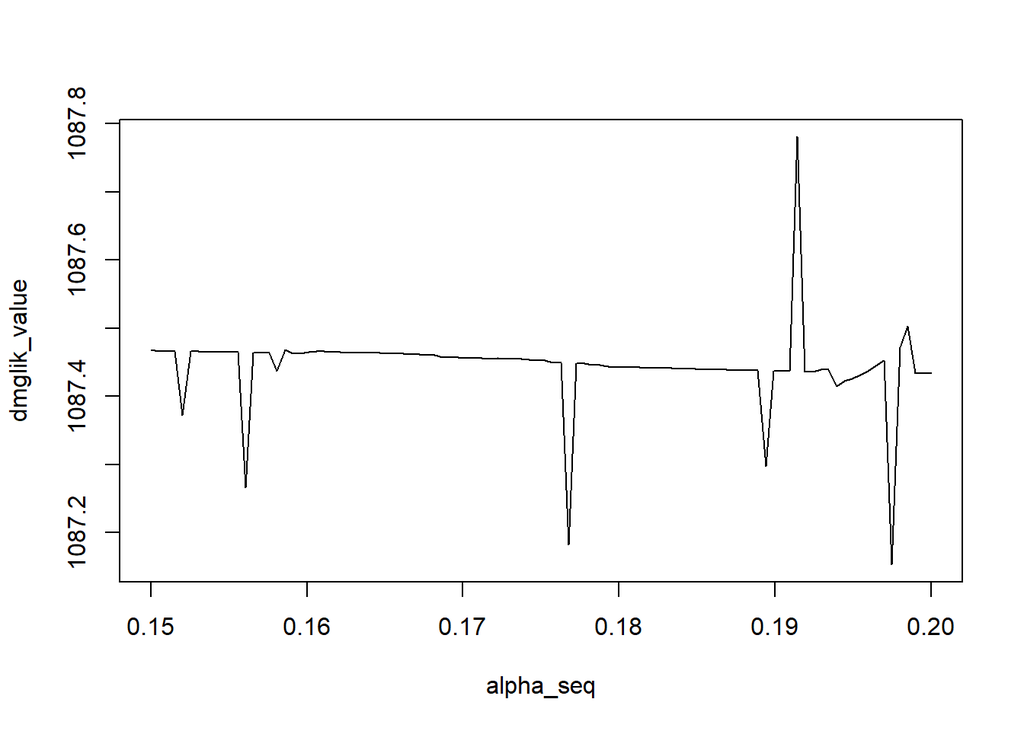

```r
negdmglik_alpha<- function(theta){

  alpha <- theta


  lik1 <- sum(dnorm(y_obs$group1,mean = mu, sd = sigma, log = TRUE))
  lik2 <- y_obs$group2 * log(
    pnorm(dmg_inverse(l,alpha,l,c,s), mean = mu, sd = sigma) -
      pnorm(l, mean = mu, sd = sigma)
  )
  #lik2 <- 0
  lik3 <- sum(sapply(y_obs$group3[-50],dmglik,alpha,l,c,s,mu,sigma))
  return(-lik1-lik2-lik3)
}

alpha_seq <- seq(from = 0.15, to = 0.2, length = 100)
dmglik_value <- sapply(alpha_seq,negdmglik_alpha)
plot(alpha_seq,dmglik_value,type = "l")
```

The bump at around alpha = 0.18 goes away. But there are still other bumps which may come from other observations caused by the unsmooth gradient.

# Try to use more accurate tuning parameter

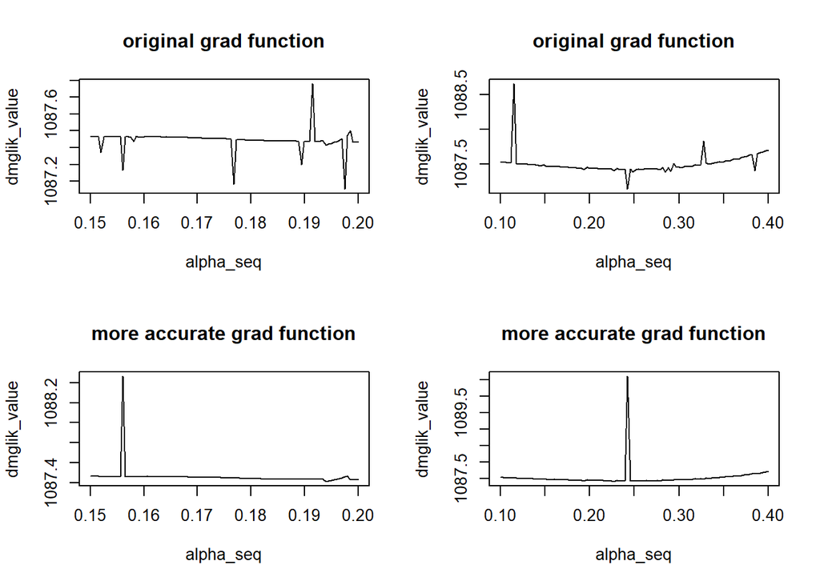

```r
par(mfrow = c(2, 2))
alpha_seq <- seq(from = 0.15, to = 0.2, length = 100)
dmglik_value <- sapply(alpha_seq,negdmglik_alpha)
plot(alpha_seq,dmglik_value,type = "l",main = "original grad function")

alpha_seq <- seq(from = 0.1, to = 0.4, length = 100)
dmglik_value <- sapply(alpha_seq,negdmglik_alpha)
plot(alpha_seq,dmglik_value,type = "l",main = "original grad function")

dmg_inverse_grad <- function(ystar,alpha,l,c,s){
  abs(numDeriv::grad(func = (function(x) dmg_inverse(x,alpha,l,c,s)),
                     x  = ystar, method.args = list(r = 8)))
}

alpha_seq <- seq(from = 0.15, to = 0.2, length = 100)
dmglik_value <- sapply(alpha_seq,negdmglik_alpha)
plot(alpha_seq,dmglik_value,type = "l",main = "more accurate grad function")

alpha_seq <- seq(from = 0.1, to = 0.4, length = 100)
dmglik_value <- sapply(alpha_seq,negdmglik_alpha)
plot(alpha_seq,dmglik_value,type = "l",main = "more accurate grad function")
```